# Avaliação Continuada - Aula 9

**Execute a célula a seguir para importar as bibliotecas de que vamos precisar e criar a variável `titanic` com nossa base de dados.**

```python
# Importando a biblioteca seaborn
import seaborn as sns
import matplotlib.pyplot as plt

# Carregando a base de dados 'titanic'
titanic = sns.load_dataset("titanic")

titanic.head()
```

|  | survived | pclass | sex | age | sibsp | parch | fare | embarked | class | who | adult_male | deck | embark_town | alive | alone |
| --- | --- | --- | --- | --- | --- | --- | --- | --- | --- | --- | --- | --- | --- | --- | --- |
| 0 | 0 | 3 | male | 22.0 | 1 | 0 | 7.2500 | S | Third | man | True | NaN | Southampton | no | False |
| 1 | 1 | 1 | female | 38.0 | 1 | 0 | 71.2833 | C | First | woman | False | C | Cherbourg | yes | False |
| 2 | 1 | 3 | female | 26.0 | 0 | 0 | 7.9250 | S | Third | woman | False | NaN | Southampton | yes | True |
| 3 | 1 | 1 | female | 35.0 | 1 | 0 | 53.1000 | S | First | woman | False | C | Southampton | yes | False |
| 4 | 0 | 3 | male | 35.0 | 0 | 0 | 8.0500 | S | Third | man | True | NaN | Southampton | no | True |

### Sobre os dados

No exercício de hoje, vamos utilizar as variáveis:

- `fare`: indica o valor pago pela passagem, em dólares ($).
- `survived`: indica se o passageiro sobreviveu ao naufrágio, sendo 1 para sobreviveu e 0 para não sobreviveu.
- `embark_town`: indica a cidade onde o passageiro embarcou no navio.
- `sex`: indica o sexo do passageiro, sendo `male` para homens e `female` para mulheres.

### Exercício de hoje - Parte 1

No exercício de hoje estamos interessados em analisar apenas os passageiros que embarcaram em Southampton.

Utilize a função `query` para selecionar apenas as linhas da base de dados que correspondem a passageiros que embarcaram enssa cidade (`"embark_town == 'Southampton'"`).

Salve o resultado em uma variável chamada `titanic_s`.

```python
# continue o código abaixo
titanic_s = titanic

# gabarito
titanic_s = titanic.query("embarked == 'S'")
```

### Exercício de hoje - Parte 2

Seu trabalho hoje é modificar o gráfico abaixo explicando o achado de nossa análise.

Antes de executar as células abaixo você deve ter feito a parte 1 do exercício.

Você irá partir do gráfico abaixo, e deverá adicionar informações para facilitar sua interpretação:

(Não mexa na célula a seguir. Há instruções e uma célular para você fazer seu código logo abaixo.)

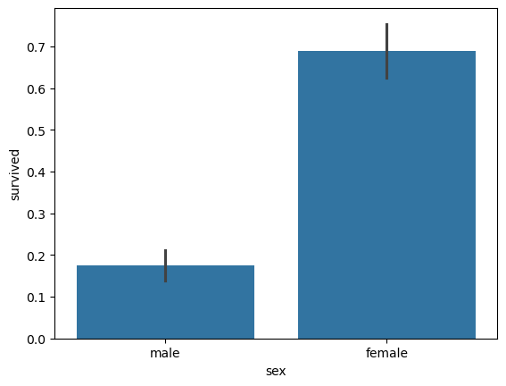

```python
sns.barplot(
    x="sex",
    y="survived",
    estimator="mean", # lembrando que por padrão o estimator é a média
    data=titanic_s,
)
```

Sua tarefa é modificar o código abaixo para:

1. Remover a barra de erro do gráfico, usando o argumento `errorbar`
2. Adicionar um título que explique qual o significado de cada barra.
3. Adicionar o valor de cada barra ao gráfico

```
[Text(0, 0, '0.174603'), Text(0, 0, '0.689655')]
```

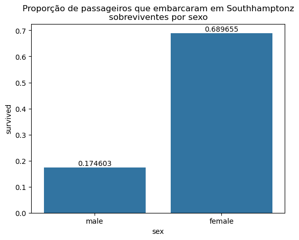

```python
fig, ax = plt.subplots()

sns.barplot(
    x="sex",
    y="survived",
    data=titanic_s,
    errorbar=None,
    ax=ax,
)

# adicione seu código abaixo

# O título deve ter algo próximo dessas informações
ax.set_title("Proporção de passageiros que embarcaram em Southhamptonz\nsobreviventes por sexo")

# Para adicionar o valores:
ax.bar_label(ax.containers[0])
```